# Punctate Report

David McGaughey

07 March, 2019

# Identifying genes with the following characteristics:

```r
library(tidyverse)
library(ComplexHeatmap)
library(viridis)
library(circlize)
library(annotables)
#peak <- read_tsv('/data/mcgaugheyd/projects/nei/hufnagel/iPSC_RPE_ATAC_Seq/peak_full/homer_GFP__not__IPSC/all/all_common_peaks.blackListed.narrowPeak.closestTSS__interesting_homer_motif.bed.gz')
expression <- read_csv('~/git/ipsc_rpe_RNA-seq/data/lsTPM_by_Line_with_Diff_Exp.tsv', col_types = 'ccdddcddd')

# iPSC
cgm_ipsc_value <- read_tsv('/data/mcgaugheyd/projects/nei/hufnagel/iPSC_RPE_ATAC_Seq/CGM/IPSC_ATAC-Seq_common_peaks.blackListed.narrowPeak.CGM_score.tsv', col_types = 'ccddddddddddddddddd') %>%
  left_join(. , expression %>% filter(Line == 'iPSC') %>% select(Gene, lsTPM), by = c('Gene_Name' = 'Gene'))
cgm_ipsc_score <- read_tsv('/data/mcgaugheyd/projects/nei/hufnagel/iPSC_RPE_ATAC_Seq/CGM/IPSC_ATAC-Seq_common_peaks.blackListed.narrowPeak.CGM_score.tsv', col_types = 'ccddddddddddddddddd') %>%
  left_join(. , expression %>% filter(Line == 'iPSC') %>% select(Gene, lsTPM), by = c('Gene_Name' = 'Gene'))

# GFP
cgm_gfp_value <- read_tsv('/data/mcgaugheyd/projects/nei/hufnagel/iPSC_RPE_ATAC_Seq/CGM/GFP_ATAC-Seq_common_peaks.blackListed.narrowPeak.CGM_score.tsv', col_types = 'ccddddddddddddddddd') %>%
  left_join(. , expression %>% filter(Line == 'GFP') %>% select(Gene, lsTPM), by = c('Gene_Name' = 'Gene'))
cgm_gfp_score <- read_tsv('/data/mcgaugheyd/projects/nei/hufnagel/iPSC_RPE_ATAC_Seq/CGM/GFP_ATAC-Seq_common_peaks.blackListed.narrowPeak.CGM_score.tsv', col_types = 'ccddddddddddddddddd') %>%
  left_join(. , expression %>% filter(Line == 'GFP') %>% select(Gene, lsTPM), by = c('Gene_Name' = 'Gene'))
cgm_gfp_h3k27ac_value <- read_tsv('/data/mcgaugheyd/projects/nei/hufnagel/iPSC_RPE_ATAC_Seq/CGM/GFP_ATAC-Seq_common_peaks.h3k27ac_intersect.blackListed.narrowPeak.CGM_score.tsv', col_types = 'ccddddddddddddddddd') %>%
  left_join(. , expression %>% filter(Line == 'GFP') %>% select(Gene, lsTPM), by = c('Gene_Name' = 'Gene'))
cgm_gfp_h3k27ac_score <- read_tsv('/data/mcgaugheyd/projects/nei/hufnagel/iPSC_RPE_ATAC_Seq/CGM/GFP_ATAC-Seq_common_peaks.h3k27ac_intersect.blackListed.narrowPeak.CGM_score.tsv', col_types = 'ccddddddddddddddddd') %>%
  left_join(. , expression %>% filter(Line == 'GFP') %>% select(Gene, lsTPM), by = c('Gene_Name' = 'Gene'))

# RFP
cgm_rfp_value <- read_tsv('/data/mcgaugheyd/projects/nei/hufnagel/iPSC_RPE_ATAC_Seq/CGM/RFP_ATAC-Seq_common_peaks.blackListed.narrowPeak.CGM_score.tsv', col_types = 'ccddddddddddddddddd') %>%
  left_join(. , expression %>% filter(Line == 'RFP') %>% select(Gene, lsTPM), by = c('Gene_Name' = 'Gene'))
cgm_rfp_score <- read_tsv('/data/mcgaugheyd/projects/nei/hufnagel/iPSC_RPE_ATAC_Seq/CGM/RFP_ATAC-Seq_common_peaks.blackListed.narrowPeak.CGM_score.tsv', col_types = 'ccddddddddddddddddd') %>%
  left_join(. , expression %>% filter(Line == 'RFP') %>% select(Gene, lsTPM), by = c('Gene_Name' = 'Gene'))
cgm_rfp_h3k27ac_value <- read_tsv('/data/mcgaugheyd/projects/nei/hufnagel/iPSC_RPE_ATAC_Seq/CGM/RFP_ATAC-Seq_common_peaks.h3k27ac_intersect.blackListed.narrowPeak.CGM_score.tsv', col_types = 'ccddddddddddddddddd') %>%
  left_join(. , expression %>% filter(Line == 'RFP') %>% select(Gene, lsTPM), by = c('Gene_Name' = 'Gene'))
cgm_rfp_h3k27ac_score <- read_tsv('/data/mcgaugheyd/projects/nei/hufnagel/iPSC_RPE_ATAC_Seq/CGM/RFP_ATAC-Seq_common_peaks.h3k27ac_intersect.blackListed.narrowPeak.CGM_score.tsv', col_types = 'ccddddddddddddddddd') %>%
  left_join(. , expression %>% filter(Line == 'RFP') %>% select(Gene, lsTPM), by = c('Gene_Name' = 'Gene'))
```

# iPSC -> GFP

ATAC + RNA-seq

Not using the h3k27ac intersection for this comparison, as the iPSC h3k27ac ChIP-seq samples I found had horrific (near zero) overlap with our iPSC ATAC data.

Narrowing in on promoter region (1000bp) with ATAC score > 100 (GSX2 has a peak score of 105 within 1000bp of TSS)

## 1. GFP - iPSC: Higher Score in TSS (> 100), Higher gene expression (>=2X or more GFP/iPSC)

```r
delta_cgm <- (cgm_gfp_score %>% mutate(`log2(TPM+1)` = log2(lsTPM+1)) %>%  select(Exon_Value:Gene_length, `log2(TPM+1)`)) -
  (cgm_ipsc_score %>% mutate(`log2(TPM+1)` = log2(lsTPM+1)) %>% select(Exon_Value:Gene_length, `log2(TPM+1)`)) %>% as.tibble()
delta_cgm$Gene_Name = cgm_gfp_score$Gene_Name
#delta_cgm$var <- apply(delta_cgm %>% select(Exon_Value:`-1e6`), 1, var)

punctate_upstream <- delta_cgm %>% #mutate(`5k_upstream` = `1000`) %>%
  filter(`1000` > 100, `log2(TPM+1)` > 1) %>% unique() %>%
  arrange(`log2(TPM+1)`)
print(nrow(punctate_upstream))
```

```
[1] 69
```

```r
punctate_upstream %>% left_join(., grch38 %>% select(symbol, description), by = c("Gene_Name" = "symbol")) %>%
  select(Gene_Name, description, `log2(TPM+1)`, Exon_Value:`-1e6`) %>% unique() %>%
  arrange(`log2(TPM+1)`) %>%
  DT::datatable()
```

|  | Gene_Name | description | log2(TPM+1) | Exon_Value | Intron_Value | 1e6 | 5e5 | 1e5 | 5e4 | 1e4 | 5000 | 1000 | -1000 | -5000 | -1e4 | -5e4 | -1e5 | -5e5 | -1e6 |
| --- | --- | --- | --- | --- | --- | --- | --- | --- | --- | --- | --- | --- | --- | --- | --- | --- | --- | --- | --- |
| 1 | PRICKLE4 | prickle planar cell polarity protein 4 [Source:HGNC Symbol;Acc:HGNC:16805] | 1.00209363894864 | -411 | 48 | 0 | 0 | 22 | 92 | 0 | -34 | 413 | 0 | 0 | 0 | -66 | -83 | 0 | 0 |
| 2 | ZHX3 | zinc fingers and homeoboxes 3 [Source:HGNC Symbol;Acc:HGNC:15935] | 1.0347586169221 | -40 | -715 | -442 | -25 | 235 | -631 | 0 | 42 | 220 | 0 | 0 | 0 | -129 | 191 | -529 | -122 |
| 3 | KIF13B | kinesin family member 13B [Source:HGNC Symbol;Acc:HGNC:14405] | 1.06170681817519 | 0 | -1552 | 0 | -577 | -95 | -124 | 0 | -190 | 164 | 0 | 0 | 0 | -47 | -542 | 234 | 0 |
| 4 | YIPF3 | Yip1 domain family member 3 [Source:HGNC Symbol;Acc:HGNC:21023] | 1.07975261469958 | 0 | 262 | 0 | 0 | 104 | 510 | 0 | 80 | 206 | 0 | 0 | 0 | 0 | 164 | 0 | 0 |
| 5 | FAM69A | family with sequence similarity 69 member A [Source:HGNC Symbol;Acc:HGNC:32213] | 1.13071928116176 | 0 | -972 | 0 | -563 | -141 | -205 | 0 | 0 | 466 | 0 | 0 | -41 | -153 | -268 | -1833 | 0 |
| 6 | RNASE4 | ribonuclease A family member 4 [Source:HGNC Symbol;Acc:HGNC:10047] | 1.13826948357196 | 137 | 61 | 0 | 0 | -259 | -961 | -31 | 0 | 230 | 0 | 0 | -65 | 229 | -39 | 0 | 0 |
| 7 | TIFA | TRAF interacting protein with forkhead associated domain [Source:HGNC Symbol;Acc:HGNC:19075] | 1.15073382155141 | 0 | 272 | -1778 | -3324 | -210 | -214 | 0 | -65 | 234 | 0 | 0 | 0 | -340 | -1906 | -2959 | 72 |
| 8 | PLCB4 | phospholipase C beta 4 [Source:HGNC Symbol;Acc:HGNC:9059] | 1.16331000654678 | 0 | -469 | -2111 | -539 | -373 | 297 | 0 | 0 | 329 | 0 | 0 | 0 | -645 | -420 | -1449 | 0 |
| 9 | SGSM2 | small G protein signaling modulator 2 [Source:HGNC Symbol;Acc:HGNC:29026] | 1.21670026033673 | -35 | 226 | 0 | 277 | -181 | -773 | 0 | 0 | 261 | 0 | 92 | 0 | -450 | -185 | 7 | 0 |
| 10 | SNX19 | sorting nexin 19 [Source:HGNC Symbol;Acc:HGNC:21532] | 1.21693271854191 | -965 | 642 | 0 | 1231 | 561 | -406 | 28 | 0 | 284 | 0 | 0 | 6 | -86 | -64 | -1601 | -2730 |

[output cut: 59 more lines]

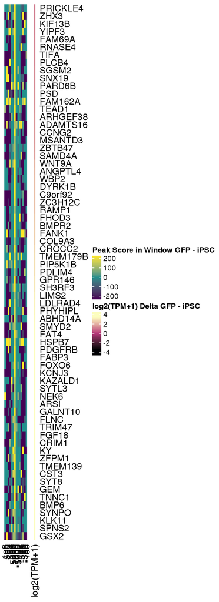

```r
# output
write(punctate_upstream %>%
            left_join(., grch38 %>% select(ensgene, symbol, description), by = c("Gene_Name" = "symbol")) %>%
            left_join(grch38_tx2gene) %>%
            pull(enstxp) %>%
            unique(),
          file = '/data/mcgaugheyd/projects/nei/hufnagel/iPSC_RPE_ATAC_Seq/punctate/punctate_analysis_1.txt')
row.names(punctate_upstream) <- punctate_upstream$Gene_Name
punctate_upstream <- punctate_upstream %>% select(`1e6`:`-1e6`, `log2(TPM+1)`)
atac_heatmap <- punctate_upstream %>% select(-`log2(TPM+1)`) %>%
  Heatmap(col = colorRamp2(c(-200, 0, 200), viridis(3)),
          cluster_columns = F,
          cluster_rows = F,
          name = 'Peak Score in Window GFP - iPSC',
          show_row_names = F)
expression_heatmap <- punctate_upstream %>% select(`log2(TPM+1)`) %>%
  Heatmap(col = colorRamp2(c(-3, 0, 3), magma(3)),
          cluster_columns = F,
          name = 'log2(TPM+1) Delta GFP - iPSC')
atac_heatmap + expression_heatmap
```

## 2. GFP - iPSC: Higher Score in TSS (> 100), less gene expression (-2X or more GFP/iPSC)

```r
delta_cgm <- (cgm_gfp_score %>% mutate(`log2(TPM+1)` = log2(lsTPM+1)) %>%  select(Exon_Value:Gene_length, `log2(TPM+1)`)) -
  (cgm_ipsc_score %>% mutate(`log2(TPM+1)` = log2(lsTPM+1)) %>% select(Exon_Value:Gene_length, `log2(TPM+1)`)) %>% as.tibble()
delta_cgm$Gene_Name = cgm_gfp_score$Gene_Name
#delta_cgm$var <- apply(delta_cgm %>% select(Exon_Value:`-1e6`), 1, var)

punctate_upstream <- delta_cgm %>% #mutate(`5k_upstream` = `1000`) %>%
  filter(`1000` > 100, `log2(TPM+1)` < -1) %>% unique() %>%
  arrange(`log2(TPM+1)`)
print(nrow(punctate_upstream))
```

```
[1] 50
```

```r
punctate_upstream %>% left_join(., grch38 %>% select(symbol, description), by = c("Gene_Name" = "symbol")) %>%
  select(Gene_Name, description, `log2(TPM+1)`, Exon_Value:`-1e6`) %>% unique() %>%
  arrange(`log2(TPM+1)`) %>%
  DT::datatable()
```

|  | Gene_Name | description | log2(TPM+1) | Exon_Value | Intron_Value | 1e6 | 5e5 | 1e5 | 5e4 | 1e4 | 5000 | 1000 | -1000 | -5000 | -1e4 | -5e4 | -1e5 | -5e5 | -1e6 |
| --- | --- | --- | --- | --- | --- | --- | --- | --- | --- | --- | --- | --- | --- | --- | --- | --- | --- | --- | --- |
| 1 | BCL6B | B-cell CLL/lymphoma 6B [Source:HGNC Symbol;Acc:HGNC:1002] | -8.2059019275403 | 87 | -337 | 0 | 0 | 0 | -211 | -415 | 0 | 198 | 0 | 0 | -215 | -241 | -357 | 0 | 0 |
| 2 | PTPN5 | protein tyrosine phosphatase, non-receptor type 5 [Source:HGNC Symbol;Acc:HGNC:9657] | -6.90488549822131 | -519 | -224 | 0 | 0 | -243 | -456 | -382 | -56 | 122 | 0 | 0 | 26 | -93 | -405 | -307 | 0 |
| 3 | SCNN1A | sodium channel epithelial 1 alpha subunit [Source:HGNC Symbol;Acc:HGNC:10599] | -4.26796359730504 | -299 | -255 | 0 | -30 | 312 | -565 | -439 | -108 | 203 | 0 | 0 | -342 | -139 | -23 | 0 | 0 |
| 4 | GRIN2B | glutamate ionotropic receptor NMDA type subunit 2B [Source:HGNC Symbol;Acc:HGNC:4586] | -3.85388280332944 | 42 | -1794 | 0 | -343 | -70 | 657 | 0 | -61 | 120 | 0 | 0 | 0 | 21 | -51 | -3060 | 0 |
| 5 | UNC79 | unc-79 homolog, NALCN channel complex subunit [Source:HGNC Symbol;Acc:HGNC:19966] | -3.76452916818262 | 283 | -1413 | 0 | -712 | -103 | 336 | 0 | 0 | 102 | 0 | -17 | -33 | -375 | -520 | -88 | 0 |
| 6 | CHST6 | carbohydrate sulfotransferase 6 [Source:HGNC Symbol;Acc:HGNC:6938] | -3.59056597524955 | -80 | -922 | 0 | -28 | -211 | -645 | -513 | 0 | 161 | 0 | 67 | 0 | -222 | -793 | 0 | 0 |
| 7 | HS3ST2 | heparan sulfate-glucosamine 3-sulfotransferase 2 [Source:HGNC Symbol;Acc:HGNC:5195] | -3.21862413546186 | 0 | -364 | 0 | -1252 | -87 | 0 | 0 | 0 | 176 | 0 | 0 | 0 | -1120 | -33 | -1137 | 0 |
| 8 | UST | uronyl 2-sulfotransferase [Source:HGNC Symbol;Acc:HGNC:17223] | -3.05669756789138 | 79 | -3918 | -691 | -2552 | -249 | -71 | 0 | 0 | 104 | 0 | -39 | -84 | -7 | -119 | -907 | 0 |
| 9 | EXOC3L1 | exocyst complex component 3 like 1 [Source:HGNC Symbol;Acc:HGNC:27540] | -2.68426481226602 | 0 | -611 | 0 | 0 | 0 | -146 | -510 | 0 | 355 | 0 | -16 | -565 | -403 | 0 | 0 | 0 |
| 10 | HMGA1 | high mobility group AT-hook 1 [Source:HGNC Symbol;Acc:HGNC:5010] | -2.68298252290945 | -43 | 85 | 0 | -1526 | -755 | -1007 | -180 | 0 | 144 | -95 | -546 | 0 | -215 | -57 | -538 | 0 |

[output cut: 40 more lines]

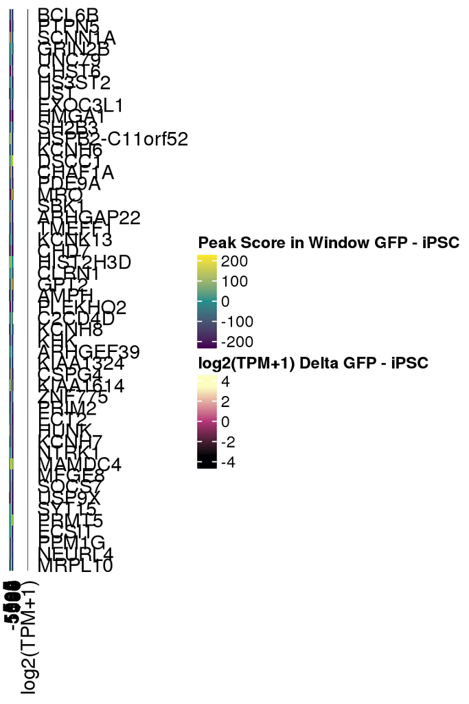

```r
# output
write(punctate_upstream %>%
            left_join(., grch38 %>% select(ensgene, symbol, description), by = c("Gene_Name" = "symbol")) %>%
            left_join(grch38_tx2gene) %>%
            pull(enstxp) %>%
            unique(),
          file = '/data/mcgaugheyd/projects/nei/hufnagel/iPSC_RPE_ATAC_Seq/punctate/punctate_analysis_2.txt')
row.names(punctate_upstream) <- punctate_upstream$Gene_Name
punctate_upstream <- punctate_upstream %>% select(`1e6`:`-1e6`, `log2(TPM+1)`)
atac_heatmap <- punctate_upstream %>% select(-`log2(TPM+1)`) %>%
  Heatmap(col = colorRamp2(c(-200, 0, 200), viridis(3)),
          cluster_columns = F,
          cluster_rows = F,
          name = 'Peak Score in Window GFP - iPSC',
          show_row_names = F)
expression_heatmap <- punctate_upstream %>% select(`log2(TPM+1)`) %>%
  Heatmap(col = colorRamp2(c(-3, 0, 3), magma(3)),
          cluster_columns = F,
          name = 'log2(TPM+1) Delta GFP - iPSC')
atac_heatmap + expression_heatmap
```

## 3. GFP - iPSC: Lower Score in TSS (< -100), higher gene expression (2X or more GFP/iPSC)

```r
delta_cgm <- (cgm_gfp_score %>% mutate(`log2(TPM+1)` = log2(lsTPM+1)) %>%  select(Exon_Value:Gene_length, `log2(TPM+1)`)) -
  (cgm_ipsc_score %>% mutate(`log2(TPM+1)` = log2(lsTPM+1)) %>% select(Exon_Value:Gene_length, `log2(TPM+1)`)) %>% as.tibble()
delta_cgm$Gene_Name = cgm_gfp_score$Gene_Name
#delta_cgm$var <- apply(delta_cgm %>% select(Exon_Value:`-1e6`), 1, var)

punctate_upstream <- delta_cgm %>% #mutate(`5k_upstream` = `1000`) %>%
  filter(`1000` < -100, `log2(TPM+1)` > 1) %>% unique() %>%
  arrange(`log2(TPM+1)`)
print(nrow(punctate_upstream))
```

```
[1] 115
```

```r
punctate_upstream %>% left_join(., grch38 %>% select(symbol, description), by = c("Gene_Name" = "symbol")) %>%
  select(Gene_Name, description, `log2(TPM+1)`, Exon_Value:`-1e6`) %>% unique() %>%
  arrange(`log2(TPM+1)`) %>%
  DT::datatable()
```

|  | Gene_Name | description | log2(TPM+1) | Exon_Value | Intron_Value | 1e6 | 5e5 | 1e5 | 5e4 | 1e4 | 5000 | 1000 | -1000 | -5000 | -1e4 | -5e4 | -1e5 | -5e5 | -1e6 |
| --- | --- | --- | --- | --- | --- | --- | --- | --- | --- | --- | --- | --- | --- | --- | --- | --- | --- | --- | --- |
| 1 | OPN5 | opsin 5 [Source:HGNC Symbol;Acc:HGNC:19992] | 1.03754063487308 | 0 | -234 | 0 | -1529 | 0 | -48 | 110 | 0 | -111 | 0 | 0 | 0 | -35 | -218 | -618 | 102 |
| 2 | SHISA5 | shisa family member 5 [Source:HGNC Symbol;Acc:HGNC:30376] | 1.04750810137978 | -184 | -613 | 0 | 0 | 0 | -868 | 0 | 796 | -343 | 0 | 3 | 0 | -171 | -638 | 0 | 0 |
| 3 | BBS7 | Bardet-Biedl syndrome 7 [Source:HGNC Symbol;Acc:HGNC:18758] | 1.06473344544276 | 0 | 0 | 0 | -630 | -384 | 253 | 0 | 0 | -629 | 0 | 0 | 39 | -245 | -1730 | -2999 | 0 |
| 4 | DGCR2 | DiGeorge syndrome critical region gene 2 [Source:HGNC Symbol;Acc:HGNC:2845] | 1.06591913131446 | -26 | -644 | 0 | -1716 | -369 | -288 | -96 | 0 | -141 | 0 | 0 | 0 | -28 | -646 | -31 | 0 |
| 5 | KRTAP5-5 | keratin associated protein 5-5 [Source:HGNC Symbol;Acc:HGNC:23601] | 1.08956099405989 | -114 | 0 | 0 | 0 | -69 | -252 | 0 | 0 | -226 | 0 | 0 | -167 | -467 | -653 | 0 | 0 |
| 6 | UCN | urocortin [Source:HGNC Symbol;Acc:HGNC:12516] | 1.09272814495907 | 147 | -221 | 0 | 0 | 0 | -693 | -50 | 73 | -113 | 0 | 0 | 0 | -215 | 0 | 0 | 0 |
| 7 | BORCS6 | BLOC-1 related complex subunit 6 [Source:HGNC Symbol;Acc:HGNC:25939] | 1.09409717059568 | -97 | 0 | 0 | 0 | 0 | -1285 | 0 | 0 | -107 | 0 | -70 | -253 | -642 | -168 | 0 | 0 |
| 8 | SOS2 | SOS Ras/Rho guanine nucleotide exchange factor 2 [Source:HGNC Symbol;Acc:HGNC:11188] | 1.11360345759204 | 0 | 73 | 0 | 27 | 114 | -241 | -68 | 0 | -642 | 235 | 0 | 0 | -163 | -338 | -1245 | 0 |
| 9 | MGAT4B | mannosyl (alpha-1,3-)-glycoprotein beta-1,4-N-acetylglucosaminyltransferase, isozyme B [Source:HGNC Symbol;Acc:HGNC:7048] | 1.12006864295757 | -61 | 81 | 0 | 0 | -76 | 60 | 0 | 48 | -345 | 0 | -88 | -50 | 80 | -323 | -837 | 0 |
| 10 | RTEL1-TNFRSF6B | RTEL1-TNFRSF6B readthrough (NMD candidate) [Source:HGNC Symbol;Acc:HGNC:44095] | 1.13229860741126 | 0 | 181 | 0 | 0 | 0 | -597 | -8 | 0 | -150 | 77 | 0 | -193 | -161 | 0 | 0 | 0 |

[output cut: 105 more lines]

[figure not shown]

```r
# output
write(punctate_upstream %>%
            left_join(., grch38 %>% select(ensgene, symbol, description), by = c("Gene_Name" = "symbol")) %>%
            left_join(grch38_tx2gene) %>%
            pull(enstxp) %>%
            unique(),
          file = '/data/mcgaugheyd/projects/nei/hufnagel/iPSC_RPE_ATAC_Seq/punctate/punctate_analysis_3.txt')
row.names(punctate_upstream) <- punctate_upstream$Gene_Name
punctate_upstream <- punctate_upstream %>% select(`1e6`:`-1e6`, `log2(TPM+1)`)
atac_heatmap <- punctate_upstream %>% select(-`log2(TPM+1)`) %>%
  Heatmap(col = colorRamp2(c(-200, 0, 200), viridis(3)),
          cluster_columns = F,
          cluster_rows = F,
          name = 'Peak Score in Window GFP - iPSC',
          show_row_names = F)
expression_heatmap <- punctate_upstream %>% select(`log2(TPM+1)`) %>%
  Heatmap(col = colorRamp2(c(-3, 0, 3), magma(3)),
          cluster_columns = F,
          name = 'log2(TPM+1) Delta GFP - iPSC')
atac_heatmap + expression_heatmap
```

## 4. GFP - iPSC: Lower Score in TSS (< -100), lower gene expression (-2X or more GFP/iPSC)

```r
delta_cgm <- (cgm_gfp_score %>% mutate(`log2(TPM+1)` = log2(lsTPM+1)) %>%  select(Exon_Value:Gene_length, `log2(TPM+1)`)) -
  (cgm_ipsc_score %>% mutate(`log2(TPM+1)` = log2(lsTPM+1)) %>% select(Exon_Value:Gene_length, `log2(TPM+1)`)) %>% as.tibble()
delta_cgm$Gene_Name = cgm_gfp_score$Gene_Name
#delta_cgm$var <- apply(delta_cgm %>% select(Exon_Value:`-1e6`), 1, var)

punctate_upstream <- delta_cgm %>% #mutate(`5k_upstream` = `1000`) %>%
  filter(`1000` < -100, `log2(TPM+1)` < -1) %>% unique() %>%
  arrange(`log2(TPM+1)`)
print(nrow(punctate_upstream))
```

```
[1] 175
```

```r
punctate_upstream %>% left_join(., grch38 %>% select(symbol, description), by = c("Gene_Name" = "symbol")) %>%
  select(Gene_Name, description, `log2(TPM+1)`, Exon_Value:`-1e6`) %>% unique() %>%
  arrange(`log2(TPM+1)`) %>%
  DT::datatable()
```

|  | Gene_Name | description | log2(TPM+1) | Exon_Value | Intron_Value | 1e6 | 5e5 | 1e5 | 5e4 | 1e4 | 5000 | 1000 | -1000 | -5000 | -1e4 | -5e4 | -1e5 | -5e5 | -1e6 |
| --- | --- | --- | --- | --- | --- | --- | --- | --- | --- | --- | --- | --- | --- | --- | --- | --- | --- | --- | --- |
| 1 | SYT6 | synaptotagmin 6 [Source:HGNC Symbol;Acc:HGNC:18638] | -10.1700338329118 | 0 | -266 | 0 | -32 | -652 | -145 | -51 | -37 | -156 | -20 | 0 | 0 | -136 | -192 | 106 | 0 |
| 2 | CAMKV | CaM kinase like vesicle associated [Source:HGNC Symbol;Acc:HGNC:28788] | -8.80646285828814 | 0 | -398 | 0 | 0 | -773 | -154 | 0 | 0 | -542 | 0 | 0 | 0 | -1003 | -1998 | 0 | 0 |
| 3 | FGD5 | FYVE, RhoGEF and PH domain containing 5 [Source:HGNC Symbol;Acc:HGNC:19117] | -8.70049979694649 | 0 | -1081 | 0 | -1778 | -96 | -566 | -98 | 0 | -104 | 0 | -52 | 0 | -156 | -366 | -761 | 0 |
| 4 | COL6A3 | collagen type VI alpha 3 chain [Source:HGNC Symbol;Acc:HGNC:2213] | -8.69293331229009 | -36 | -927 | -332 | -2900 | -46 | 0 | -57 | 0 | -113 | 0 | 0 | -365 | -265 | -1186 | -1758 | 0 |
| 5 | CACNG7 | calcium voltage-gated channel auxiliary subunit gamma 7 [Source:HGNC Symbol;Acc:HGNC:13626] | -8.62719945699857 | -972 | -193 | 0 | -433 | -127 | -1597 | -834 | -92 | -301 | 0 | -38 | -37 | -844 | -132 | 0 | 0 |
| 6 | SALL3 | spalt like transcription factor 3 [Source:HGNC Symbol;Acc:HGNC:10527] | -7.755301012646 | -93 | -88 | -1692 | -1961 | -217 | -328 | -82 | 0 | -138 | 0 | -75 | -48 | -674 | -447 | -3254 | 0 |
| 7 | TRIM71 | tripartite motif containing 71 [Source:HGNC Symbol;Acc:HGNC:32669] | -7.66666626462017 | -150 | -1231 | 0 | -1985 | -119 | -930 | 0 | 0 | -769 | 0 | -1026 | 193 | -603 | -228 | -1516 | 0 |
| 8 | ADCY2 | adenylate cyclase 2 [Source:HGNC Symbol;Acc:HGNC:233] | -7.58759937228499 | 0 | -4936 | -2972 | -2391 | -539 | -346 | 0 | -65 | -342 | 0 | -86 | 0 | -793 | -251 | -2584 | -1067 |
| 9 | SCGB3A2 | secretoglobin family 3A member 2 [Source:HGNC Symbol;Acc:HGNC:18391] | -7.50913486449889 | 0 | -723 | -1367 | -5076 | -999 | -262 | -46 | 0 | -365 | -126 | -68 | 0 | -205 | -1188 | -1118 | 0 |
| 10 | SHISA6 | shisa family member 6 [Source:HGNC Symbol;Acc:HGNC:34491] | -7.32270253845843 | -130 | -261 | 0 | -223 | -40 | 0 | 0 | 0 | -200 | 0 | 0 | 0 | -568 | -127 | -1457 | 90 |

[output cut: 165 more lines]

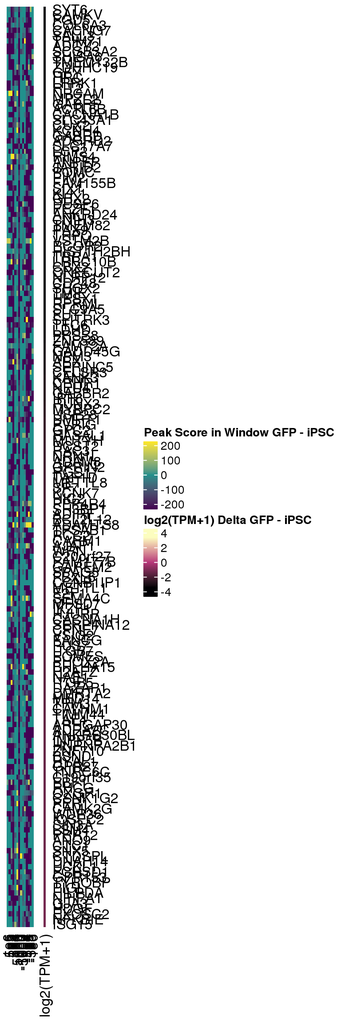

```r
# output
write(punctate_upstream %>%
            left_join(., grch38 %>% select(ensgene, symbol, description), by = c("Gene_Name" = "symbol")) %>%
            left_join(grch38_tx2gene) %>%
            pull(enstxp) %>%
            unique(),
          file = '/data/mcgaugheyd/projects/nei/hufnagel/iPSC_RPE_ATAC_Seq/punctate/punctate_analysis_4.txt')
row.names(punctate_upstream) <- punctate_upstream$Gene_Name
punctate_upstream <- punctate_upstream %>% select(`1e6`:`-1e6`, `log2(TPM+1)`)
atac_heatmap <- punctate_upstream %>% select(-`log2(TPM+1)`) %>%
  Heatmap(col = colorRamp2(c(-200, 0, 200), viridis(3)),
          cluster_columns = F,
          cluster_rows = F,
          name = 'Peak Score in Window GFP - iPSC',
          show_row_names = F)
expression_heatmap <- punctate_upstream %>% select(`log2(TPM+1)`) %>%
  Heatmap(col = colorRamp2(c(-3, 0, 3), magma(3)),
          cluster_columns = F,
          name = 'log2(TPM+1) Delta GFP - iPSC')
atac_heatmap + expression_heatmap
```

# GFP vs RFP

Modified approach from `trends.Rmd` where the filtering is based upon evaluating two settings: - Within 1000bp - Within 100,000bp - (Not using the entire region)

## 5. GFP - RFP: Higher Peak Score (1000bp > 30 or 100k > 200) and Higher Expression (>0.5 log2(TPM) GFP - RFP)

**WITH h3k27ac Intersection**

0.5 log(TPM+1) delta set as GSX2 is just over 0.5 log2(TPM+1) overexpressed GFP - RFP

```r
delta_cgm <- (cgm_gfp_h3k27ac_value %>% mutate(`log2(TPM+1)` = log2(lsTPM+1)) %>%  select(Exon_Value:Gene_length, `log2(TPM+1)`)) -
             (cgm_rfp_h3k27ac_value %>% mutate(`log2(TPM+1)` = log2(lsTPM+1)) %>% select(Exon_Value:Gene_length, `log2(TPM+1)`)) %>% as.tibble()
delta_cgm$Gene_Name = cgm_gfp_h3k27ac_score$Gene_Name
#delta_cgm$var <- apply(delta_cgm %>% select(Exon_Value:`-1e6`), 1, var)

delta_cgm <- delta_cgm %>% mutate(Promoter = `1000`,
                                  Upstream100K = `1000` + `5000` + `1e4` + `5e4` + `1e5`) %>%
  unique()
#delta_cgm %>% select(Exon_Value:`-1e6`) %>% rowSums(na.rm=TRUE) -> delta_cgm$All


punctate_upstream <- delta_cgm %>%
  filter(`log2(TPM+1)` > 0.5) %>% filter(Promoter > 30 | Upstream100K > 200) %>%
  arrange(`log2(TPM+1)`)
punctate_upstream %>% left_join(., grch38 %>% select(symbol, description), by = c("Gene_Name" = "symbol")) %>%
  select(Gene_Name, description, `log2(TPM+1)`, Promoter, Upstream100K, Exon_Value:`-1e6`) %>%
  DT::datatable()
```

|  | Gene_Name | description | log2(TPM+1) | Promoter | Upstream100K | Exon_Value | Intron_Value | 1e6 | 5e5 | 1e5 | 5e4 | 1e4 | 5000 | 1000 | -1000 | -5000 | -1e4 | -5e4 | -1e5 | -5e5 | -1e6 |
| --- | --- | --- | --- | --- | --- | --- | --- | --- | --- | --- | --- | --- | --- | --- | --- | --- | --- | --- | --- | --- | --- |
| 1 | LEKR1 | leucine, glutamate and lysine rich 1 [Source:HGNC Symbol;Acc:HGNC:33765] | 0.514505861082944 | 0 | 366 | 366 | -492 | 0 | -424 | 225 | 60 | 81 | 0 | 0 | 0 | 0 | 0 | -47 | -74 | -544 | 4 |
| 2 | SLC46A3 | solute carrier family 46 member 3 [Source:HGNC Symbol;Acc:HGNC:27501] | 0.518633195153377 | 0 | 783 | 0 | 800 | 0 | 163 | 0 | 458 | 325 | 0 | 0 | 0 | 0 | 0 | 346 | 0 | 77 | 1367 |
| 3 | ENPP5 | ectonucleotide pyrophosphatase/phosphodiesterase 5 (putative) [Source:HGNC Symbol;Acc:HGNC:13717] | 0.52240017016122 | 0 | 595 | 0 | 484 | 909 | 355 | 97 | 498 | 0 | 0 | 0 | 0 | 0 | 0 | 0 | 0 | 402 | 0 |
| 4 | CD200R1L | CD200 receptor 1 like [Source:HGNC Symbol;Acc:HGNC:24665] | 0.527130849731956 | 0 | 252 | 0 | 72 | 0 | 1233 | 0 | 252 | 0 | 0 | 0 | 0 | 0 | 0 | 0 | 0 | 1126 | 0 |
| 5 | MS4A4E | membrane spanning 4-domains A4E [Source:HGNC Symbol;Acc:HGNC:14284] | 0.543192625970312 | 0 | 284 | 0 | 41 | 0 | 0 | 284 | 0 | 0 | 0 | 0 | 0 | 0 | 0 | 0 | 467 | 0 | 0 |
| 6 | KIAA1324 | KIAA1324 [Source:HGNC Symbol;Acc:HGNC:29618] | 0.543903570794053 | 76 | -271 | 0 | -16 | 0 | 0 | -240 | -107 | 0 | 0 | 76 | 0 | 0 | -165 | 18 | -115 | 0 | 0 |
| 7 | FHOD3 | formin homology 2 domain containing 3 [Source:HGNC Symbol;Acc:HGNC:26178] | 0.551669594514458 | 188 | 188 | 0 | -374 | 0 | -394 | 0 | 0 | 0 | 0 | 188 | 0 | 0 | -20 | -81 | 0 | -44 | -828 |
| 8 | CLUL1 | clusterin like 1 [Source:HGNC Symbol;Acc:HGNC:2096] | 0.552259462858491 | 0 | 740 | 0 | 29 | 0 | 2150 | 164 | 576 | 0 | 0 | 0 | 0 | 0 | 218 | 0 | 234 | 494 | 250 |
| 9 | ZNF366 | zinc finger protein 366 [Source:HGNC Symbol;Acc:HGNC:18316] | 0.556358410362042 | 0 | 259 | 0 | 45 | 0 | 2845 | 39 | 220 | 0 | 0 | 0 | 0 | 0 | 0 | 171 | 202 | 929 | 0 |
| 10 | ADAMTSL2 | ADAMTS like 2 [Source:HGNC Symbol;Acc:HGNC:14631] | 0.570087289620642 | 0 | 710 | -92 | 117 | 0 | 0 | 626 | 27 | 43 | 14 | 0 | 0 | 0 | 0 | 0 | 0 | 9 | 0 |

[output cut: 35 more lines]

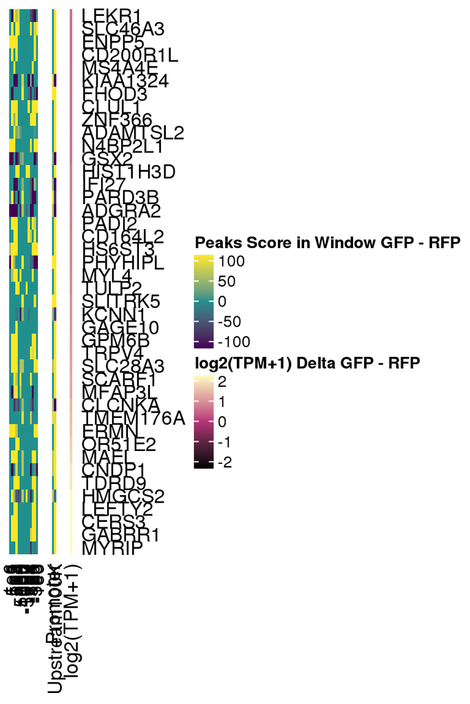

```r
# output
write(punctate_upstream %>%
            left_join(., grch38 %>% select(ensgene, symbol, description), by = c("Gene_Name" = "symbol")) %>%
            left_join(grch38_tx2gene) %>%
            pull(enstxp) %>%
            unique(),
          file = '/data/mcgaugheyd/projects/nei/hufnagel/iPSC_RPE_ATAC_Seq/punctate/punctate_analysis_5.txt')
row.names(punctate_upstream) <- punctate_upstream$Gene_Name
punctate_upstream <- punctate_upstream %>% select(`1e6`:`-1e6`, `log2(TPM+1)`, Promoter, Upstream100K)
atac_heatmap <- punctate_upstream %>% select(-`log2(TPM+1)`, -Promoter, -Upstream100K) %>%
  Heatmap(col = colorRamp2(c(-100, 0, 100), viridis(3)),
          cluster_columns = F,
          name = 'Peaks Score in Window GFP - RFP',
          cluster_rows = F,
          show_row_names = F)

region_heatmap <- punctate_upstream %>% select(Promoter, Upstream100K) %>%
  Heatmap(col = colorRamp2(c(-100, 0, 100), viridis(3)),
          cluster_columns = F,
          name = 'Aggregation Peak Score GFP - RFP',
          show_row_names = F,
          cluster_rows = F,
          show_heatmap_legend = F)

expression_heatmap <- punctate_upstream %>% select(`log2(TPM+1)`) %>%
  Heatmap(col = colorRamp2(c(-2, 0, 2), magma(3)),
          cluster_columns = F,
          cluster_rows = F,
          name = 'log2(TPM+1) Delta GFP - RFP')
atac_heatmap + region_heatmap + expression_heatmap
```

## 6. GFP - RFP: Higher Peak Score (1000bp > 30 or 100k > 200) and Lower Expression (< -0.5 log2(TPM) GFP - RFP)

Notice how there are fewer…which is good, as ATAC + h3k27Ac is a canonical “activation” signal

```r
delta_cgm <- (cgm_gfp_h3k27ac_value %>% mutate(`log2(TPM+1)` = log2(lsTPM+1)) %>%  select(Exon_Value:Gene_length, `log2(TPM+1)`)) -
             (cgm_rfp_h3k27ac_value %>% mutate(`log2(TPM+1)` = log2(lsTPM+1)) %>% select(Exon_Value:Gene_length, `log2(TPM+1)`)) %>% as.tibble()
delta_cgm$Gene_Name = cgm_gfp_h3k27ac_value$Gene_Name
#delta_cgm$var <- apply(delta_cgm %>% select(Exon_Value:`-1e6`), 1, var)

delta_cgm <- delta_cgm %>% mutate(Promoter = `1000`,
                                  Upstream100K = `1000` + `5000` + `1e4` + `5e4` + `1e5`) %>%
  unique()
#delta_cgm %>% select(Exon_Value:`-1e6`) %>% rowSums(na.rm=TRUE) -> delta_cgm$All


punctate_upstream <- delta_cgm %>%
  filter(`log2(TPM+1)` < -0.5) %>% filter(Promoter > 30 | Upstream100K > 200) %>%
  arrange(`log2(TPM+1)`)
punctate_upstream %>% left_join(., grch38 %>% select(symbol, description), by = c("Gene_Name" = "symbol")) %>%
  select(Gene_Name, description, `log2(TPM+1)`, Promoter, Upstream100K, Exon_Value:`-1e6`) %>%
  DT::datatable()
```

|  | Gene_Name | description | log2(TPM+1) | Promoter | Upstream100K | Exon_Value | Intron_Value | 1e6 | 5e5 | 1e5 | 5e4 | 1e4 | 5000 | 1000 | -1000 | -5000 | -1e4 | -5e4 | -1e5 | -5e5 | -1e6 |
| --- | --- | --- | --- | --- | --- | --- | --- | --- | --- | --- | --- | --- | --- | --- | --- | --- | --- | --- | --- | --- | --- |
| 1 | TNFSF12-TNFSF13 | TNFSF12-TNFSF13 readthrough [Source:HGNC Symbol;Acc:HGNC:33537] | -1.98389869803395 | 57 | 57 | 0 | 44 | 0 | 0 | 0 | 0 | 0 | 0 | 57 | 0 | 0 | 0 | -231 | 0 | 0 | 0 |
| 2 | ZMAT4 | zinc finger matrin-type 4 [Source:HGNC Symbol;Acc:HGNC:25844] | -1.14904064353499 | 68 | 68 | 0 | -42 | -77 | -73 | 0 | 0 | 0 | 0 | 68 | 0 | 0 | 0 | 0 | 0 | -180 | 0 |
| 3 | UNC79 | unc-79 homolog, NALCN channel complex subunit [Source:HGNC Symbol;Acc:HGNC:19966] | -1.01051908950141 | 102 | -82 | 167 | 0 | 0 | -257 | 0 | -184 | 0 | 0 | 102 | 0 | 0 | 0 | 0 | 0 | 0 | 0 |
| 4 | UNC79 | unc-79 homolog, NALCN channel complex subunit [Source:HGNC Symbol;Acc:HGNC:19966] | -1.01051908950141 | 102 | -82 | 167 | 0 | 0 | -257 | 0 | -184 | 0 | 0 | 102 | 0 | 0 | 0 | 0 | 0 | 0 | 0 |
| 5 | GTF2A1L | general transcription factor IIA subunit 1 like [Source:HGNC Symbol;Acc:HGNC:30727] | -0.816898977925988 | 0 | 358 | 0 | -157 | 0 | -213 | 279 | 79 | 0 | 0 | 0 | 0 | 0 | 0 | 0 | 0 | -98 | -46 |
| 6 | SHISA2 | shisa family member 2 [Source:HGNC Symbol;Acc:HGNC:20366] | -0.796464941898811 | 0 | 293 | 0 | 86 | 0 | 475 | 149 | 144 | 0 | 0 | 0 | 132 | 0 | 0 | 102 | 0 | 1121 | 791 |
| 7 | CNN1 | calponin 1 [Source:HGNC Symbol;Acc:HGNC:2155] | -0.769502568087358 | 0 | 978 | 0 | 32 | 0 | 0 | 0 | 410 | 513 | 55 | 0 | 0 | 0 | 309 | 535 | 402 | 0 | 0 |
| 8 | NWD1 | NACHT and WD repeat domain containing 1 [Source:HGNC Symbol;Acc:HGNC:27619] | -0.765095521628784 | 80 | -34 | 0 | 40 | 0 | 0 | -114 | 0 | 0 | 0 | 80 | 0 | 0 | 56 | -35 | -218 | 22 | 0 |
| 9 | SPO11 | SPO11, initiator of meiotic double stranded breaks [Source:HGNC Symbol;Acc:HGNC:11250] | -0.691985523835053 | 0 | 695 | 0 | 188 | 0 | 1656 | 198 | 234 | 263 | 0 | 0 | 0 | 0 | 247 | 42 | 271 | 0 | 0 |
| 10 | ROPN1 | rhophilin associated tail protein 1 [Source:HGNC Symbol;Acc:HGNC:17692] | -0.593821483957933 | 0 | 1630 | 0 | 131 | 0 | 1558 | 680 | 0 | 950 | 0 | 0 | 0 | 0 | 0 | 97 | 0 | 872 | 119 |

[output cut: 5 more lines]

[figure not shown]

```r
# output
write(punctate_upstream %>%
            left_join(., grch38 %>% select(ensgene, symbol, description), by = c("Gene_Name" = "symbol")) %>%
            left_join(grch38_tx2gene) %>%
            pull(enstxp) %>%
            unique(),
          file = '/data/mcgaugheyd/projects/nei/hufnagel/iPSC_RPE_ATAC_Seq/punctate/punctate_analysis_6.txt')
row.names(punctate_upstream) <- punctate_upstream$Gene_Name
punctate_upstream <- punctate_upstream %>% select(`1e6`:`-1e6`, `log2(TPM+1)`, Promoter, Upstream100K)
atac_heatmap <- punctate_upstream %>% select(-`log2(TPM+1)`, -Promoter, -Upstream100K) %>%
  Heatmap(col = colorRamp2(c(-100, 0, 100), viridis(3)),
          cluster_columns = F,
          name = 'Peaks Score in Window GFP - RFP',
          cluster_rows = F,
          show_row_names = F)

region_heatmap <- punctate_upstream %>% select(Promoter, Upstream100K) %>%
  Heatmap(col = colorRamp2(c(-100, 0, 100), viridis(3)),
          cluster_columns = F,
          name = 'Aggregation Peak Score GFP - RFP',
          show_row_names = F,
          cluster_rows = F,
          show_heatmap_legend = F)

expression_heatmap <- punctate_upstream %>% select(`log2(TPM+1)`) %>%
  Heatmap(col = colorRamp2(c(-2, 0, 2), magma(3)),
          cluster_columns = F,
          cluster_rows = F,
          name = 'log2(TPM+1) Delta GFP - RFP')
atac_heatmap + region_heatmap + expression_heatmap
```

## 7. GFP - RFP: Lower Peak Score (1000bp < -30 or 100k < -200) and Higher Expression (>1 log2(TPM) GFP - RFP)

I’ve increased the stringency for log2(TPM+1) change from 0.5 to 1, as there are way too many results.

```r
delta_cgm <- (cgm_gfp_h3k27ac_value %>% mutate(`log2(TPM+1)` = log2(lsTPM+1)) %>%  select(Exon_Value:Gene_length, `log2(TPM+1)`)) -
             (cgm_rfp_h3k27ac_value %>% mutate(`log2(TPM+1)` = log2(lsTPM+1)) %>% select(Exon_Value:Gene_length, `log2(TPM+1)`)) %>% as.tibble()
delta_cgm$Gene_Name = cgm_gfp_h3k27ac_value$Gene_Name
#delta_cgm$var <- apply(delta_cgm %>% select(Exon_Value:`-1e6`), 1, var)

delta_cgm <- delta_cgm %>% mutate(Promoter = `1000`,
                                  Upstream100K = `1000` + `5000` + `1e4` + `5e4` + `1e5`) %>%
  unique()
#delta_cgm %>% select(Exon_Value:`-1e6`) %>% rowSums(na.rm=TRUE) -> delta_cgm$All


punctate_upstream <- delta_cgm %>%
  filter(`log2(TPM+1)` > 1) %>% filter(Promoter < -30 | Upstream100K < -200) %>%
  arrange(`log2(TPM+1)`)
punctate_upstream %>% left_join(., grch38 %>% select(symbol, description), by = c("Gene_Name" = "symbol")) %>%
  select(Gene_Name, description, `log2(TPM+1)`, Promoter, Upstream100K, Exon_Value:`-1e6`) %>%
  DT::datatable()
```

|  | Gene_Name | description | log2(TPM+1) | Promoter | Upstream100K | Exon_Value | Intron_Value | 1e6 | 5e5 | 1e5 | 5e4 | 1e4 | 5000 | 1000 | -1000 | -5000 | -1e4 | -5e4 | -1e5 | -5e5 | -1e6 |
| --- | --- | --- | --- | --- | --- | --- | --- | --- | --- | --- | --- | --- | --- | --- | --- | --- | --- | --- | --- | --- | --- |
| 1 | RBKS | ribokinase [Source:HGNC Symbol;Acc:HGNC:30325] | 1.00700517720824 | 0 | -270 | -98 | -192 | 0 | 0 | -52 | -98 | -120 | 0 | 0 | 0 | 0 | 0 | 56 | 0 | -89 | 0 |
| 2 | LDLRAD1 | low density lipoprotein receptor class A domain containing 1 [Source:HGNC Symbol;Acc:HGNC:32069] | 1.00993495399666 | 0 | -343 | 0 | 8 | 0 | -47 | -371 | 28 | 0 | 0 | 0 | 0 | 0 | -13 | -62 | 0 | 0 | 0 |
| 3 | CCR9 | C-C motif chemokine receptor 9 [Source:HGNC Symbol;Acc:HGNC:1610] | 1.01034741950316 | 0 | -234 | 0 | -39 | 0 | -101 | -52 | -182 | 0 | 0 | 0 | 0 | 0 | 0 | -160 | -188 | 0 | 0 |
| 4 | MFRP | membrane frizzled-related protein [Source:HGNC Symbol;Acc:HGNC:18121] | 1.01544852271013 | -107 | -209 | 0 | -19 | 0 | 0 | 0 | -39 | 0 | -63 | -107 | 0 | 0 | 39 | -118 | 0 | -518 | 0 |
| 5 | MFRP | membrane frizzled-related protein [Source:HGNC Symbol;Acc:HGNC:18121] | 1.01544852271013 | -107 | -209 | 0 | -19 | 0 | 0 | 0 | -39 | 0 | -63 | -107 | 0 | 0 | 39 | -118 | 0 | -518 | 0 |
| 6 | CATSPERB | cation channel sperm associated auxiliary subunit beta [Source:HGNC Symbol;Acc:HGNC:20500] | 1.02579676434149 | 0 | -270 | 0 | -26 | 0 | -45 | -234 | 26 | -62 | 0 | 0 | 0 | 0 | 0 | 0 | -448 | 30 | 0 |
| 7 | CATSPERB | cation channel sperm associated auxiliary subunit beta [Source:HGNC Symbol;Acc:HGNC:20500] | 1.02579676434149 | 0 | -270 | 0 | -26 | 0 | -45 | -234 | 26 | -62 | 0 | 0 | 0 | 0 | 0 | 0 | -448 | 30 | 0 |
| 8 | PRSS33 | protease, serine 33 [Source:HGNC Symbol;Acc:HGNC:30405] | 1.04199678917973 | 0 | -228 | 0 | 1 | 0 | -72 | -85 | -100 | -43 | 0 | 0 | 0 | 0 | -18 | -89 | 39 | 0 | 0 |
| 9 | GNB3 | G protein subunit beta 3 [Source:HGNC Symbol;Acc:HGNC:4400] | 1.04739600502925 | 0 | -330 | 0 | 48 | 0 | 0 | 0 | -265 | 0 | -65 | 0 | 0 | -84 | 0 | -282 | 0 | 0 | 0 |
| 10 | CYP27A1 | cytochrome P450 family 27 subfamily A member 1 [Source:HGNC Symbol;Acc:HGNC:2605] | 1.0494461009889 | 0 | -287 | -81 | 25 | 0 | 0 | -265 | -22 | 0 | 0 | 0 | 0 | 0 | 0 | 0 | -132 | 0 | 0 |

[output cut: 47 more lines]

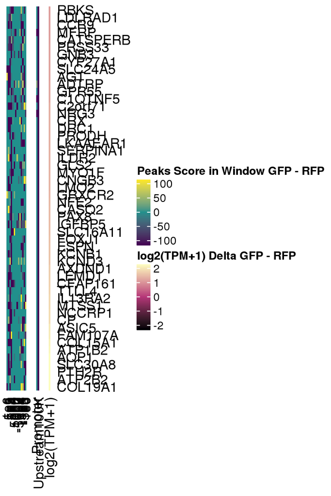

```r
# output
write(punctate_upstream %>%
            left_join(., grch38 %>% select(ensgene, symbol, description), by = c("Gene_Name" = "symbol")) %>%
            left_join(grch38_tx2gene) %>%
            pull(enstxp) %>%
            unique(),
          file = '/data/mcgaugheyd/projects/nei/hufnagel/iPSC_RPE_ATAC_Seq/punctate/punctate_analysis_7.txt')
row.names(punctate_upstream) <- punctate_upstream$Gene_Name
punctate_upstream <- punctate_upstream %>% select(`1e6`:`-1e6`, `log2(TPM+1)`, Promoter, Upstream100K)
atac_heatmap <- punctate_upstream %>% select(-`log2(TPM+1)`, -Promoter, -Upstream100K) %>%
  Heatmap(col = colorRamp2(c(-100, 0, 100), viridis(3)),
          cluster_columns = F,
          name = 'Peaks Score in Window GFP - RFP',
          cluster_rows = F,
          show_row_names = F)

region_heatmap <- punctate_upstream %>% select(Promoter, Upstream100K) %>%
  Heatmap(col = colorRamp2(c(-100, 0, 100), viridis(3)),
          cluster_columns = F,
          name = 'Aggregation Peak Score GFP - RFP',
          show_row_names = F,
          cluster_rows = F,
          show_heatmap_legend = F)

expression_heatmap <- punctate_upstream %>% select(`log2(TPM+1)`) %>%
  Heatmap(col = colorRamp2(c(-2, 0, 2), magma(3)),
          cluster_columns = F,
          cluster_rows = F,
          name = 'log2(TPM+1) Delta GFP - RFP')
atac_heatmap + region_heatmap + expression_heatmap
```

## 8. GFP - RFP: Lower Peak Score (1000bp < -30 or 100k < -200) and Lower Expression (< -1 log2(TPM) GFP - RFP)

I’ve increased the stringency for log2(TPM+1) change from 0.5 to 1, as there are way too many results.

```r
delta_cgm <- (cgm_gfp_h3k27ac_value %>% mutate(`log2(TPM+1)` = log2(lsTPM+1)) %>%  select(Exon_Value:Gene_length, `log2(TPM+1)`)) -
             (cgm_rfp_h3k27ac_value %>% mutate(`log2(TPM+1)` = log2(lsTPM+1)) %>% select(Exon_Value:Gene_length, `log2(TPM+1)`)) %>% as.tibble()
delta_cgm$Gene_Name = cgm_gfp_h3k27ac_value$Gene_Name
#delta_cgm$var <- apply(delta_cgm %>% select(Exon_Value:`-1e6`), 1, var)

delta_cgm <- delta_cgm %>% mutate(Promoter = `1000`,
                                  Upstream100K = `1000` + `5000` + `1e4` + `5e4` + `1e5`) %>%
  unique()
#delta_cgm %>% select(Exon_Value:`-1e6`) %>% rowSums(na.rm=TRUE) -> delta_cgm$All


punctate_upstream <- delta_cgm %>%
  filter(`log2(TPM+1)` < -1) %>% filter(Promoter < -30 | Upstream100K < -200) %>%
  arrange(`log2(TPM+1)`)
punctate_upstream %>% left_join(., grch38 %>% select(symbol, description), by = c("Gene_Name" = "symbol")) %>%
  select(Gene_Name, description, `log2(TPM+1)`, Promoter, Upstream100K, Exon_Value:`-1e6`) %>%
  DT::datatable()
```

|  | Gene_Name | description | log2(TPM+1) | Promoter | Upstream100K | Exon_Value | Intron_Value | 1e6 | 5e5 | 1e5 | 5e4 | 1e4 | 5000 | 1000 | -1000 | -5000 | -1e4 | -5e4 | -1e5 | -5e5 | -1e6 |
| --- | --- | --- | --- | --- | --- | --- | --- | --- | --- | --- | --- | --- | --- | --- | --- | --- | --- | --- | --- | --- | --- |
| 1 | CABP1 | calcium binding protein 1 [Source:HGNC Symbol;Acc:HGNC:1384] | -1.48874451502787 | 0 | -212 | 0 | -66 | 0 | 0 | -118 | -94 | 0 | 0 | 0 | 0 | 16 | 0 | -236 | -346 | -96 | 0 |
| 2 | ADRA1B | adrenoceptor alpha 1B [Source:HGNC Symbol;Acc:HGNC:278] | -1.15103987171068 | 0 | -203 | 336 | -352 | 95 | -56 | -203 | 0 | 0 | 0 | 0 | 0 | 0 | 0 | -256 | 0 | -3 | 0 |
| 3 | SCN7A | sodium voltage-gated channel alpha subunit 7 [Source:HGNC Symbol;Acc:HGNC:10594] | -1.13101071965607 | 0 | -315 | 0 | -63 | 0 | -400 | 0 | -315 | 0 | 0 | 0 | 0 | 0 | 0 | 0 | 0 | -33 | -454 |
| 4 | ODF3L1 | outer dense fiber of sperm tails 3 like 1 [Source:HGNC Symbol;Acc:HGNC:28735] | -1.12287256597555 | 0 | -2810 | -222 | 0 | 0 | 0 | -2059 | -683 | 0 | -68 | 0 | 0 | 0 | -112 | -1001 | 0 | -511 | 0 |
| 5 | TRPM2 | transient receptor potential cation channel subfamily M member 2 [Source:HGNC Symbol;Acc:HGNC:12339] | -1.12202526878038 | 0 | -245 | 0 | -40 | 0 | 0 | 0 | -245 | 0 | 0 | 0 | 0 | 0 | 0 | -76 | 0 | 0 | 0 |
| 6 | HECW2 | HECT, C2 and WW domain containing E3 ubiquitin protein ligase 2 [Source:HGNC Symbol;Acc:HGNC:29853] | -1.02007799812144 | 0 | -467 | 64 | -160 | 276 | 128 | 0 | -467 | 0 | 0 | 0 | 0 | 0 | 0 | 0 | 37 | -325 | 0 |

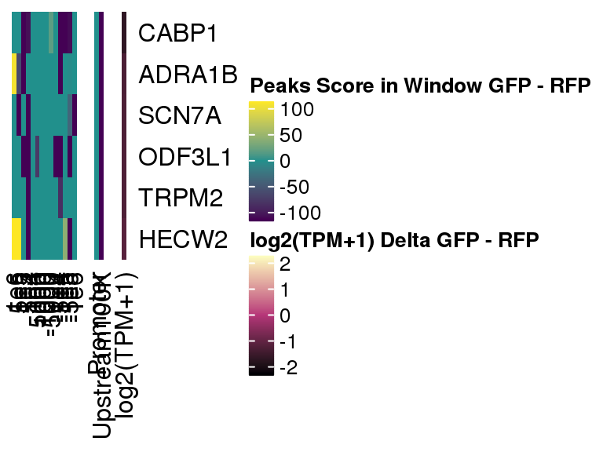

```r
# output
write(punctate_upstream %>%
            left_join(., grch38 %>% select(ensgene, symbol, description), by = c("Gene_Name" = "symbol")) %>%
            left_join(grch38_tx2gene) %>%
            pull(enstxp) %>%
            unique(),
          file = '/data/mcgaugheyd/projects/nei/hufnagel/iPSC_RPE_ATAC_Seq/punctate/punctate_analysis_8.txt')
row.names(punctate_upstream) <- punctate_upstream$Gene_Name
punctate_upstream <- punctate_upstream %>% select(`1e6`:`-1e6`, `log2(TPM+1)`, Promoter, Upstream100K)
atac_heatmap <- punctate_upstream %>% select(-`log2(TPM+1)`, -Promoter, -Upstream100K) %>%
  Heatmap(col = colorRamp2(c(-100, 0, 100), viridis(3)),
          cluster_columns = F,
          name = 'Peaks Score in Window GFP - RFP',
          cluster_rows = F,
          show_row_names = F)

region_heatmap <- punctate_upstream %>% select(Promoter, Upstream100K) %>%
  Heatmap(col = colorRamp2(c(-100, 0, 100), viridis(3)),
          cluster_columns = F,
          name = 'Aggregation Peak Score GFP - RFP',
          show_row_names = F,
          cluster_rows = F,
          show_heatmap_legend = F)

expression_heatmap <- punctate_upstream %>% select(`log2(TPM+1)`) %>%
  Heatmap(col = colorRamp2(c(-2, 0, 2), magma(3)),
          cluster_columns = F,
          cluster_rows = F,
          name = 'log2(TPM+1) Delta GFP - RFP')
atac_heatmap + region_heatmap + expression_heatmap
```